# Mixture Model Analysis of Temporal Order Judgment

Cédric Foucault

## Description of the design

### Type of trials

Chaque essai a 3 issues possibles : 1. soit la cible n’a pas été perçue consciemment ; 2. soit la cible a été perçue consciemment directement ; 3. soit la cible a été perçue consciemment rétrospectivement grâce à la cue. Dans la suite, on qualifiera ces 3 types d’essai par 1. “guess”, 2. “seen”, et 3. “retro”

### Hypotheses

Nous avons deux hypothèses alternatives :

**(CA)**

Conscious Access : Il y a confusion du moment où l’on juge que la cible est apparue avec le moment où l’on en a pris conscience.

**(TM)**

Time Marker : Un processus préconscient encode un marqueur temporel de la cible auquel on peut faire référence plus tard pour juger du moment où la cible est apparue, indépendemment du moment où l’on en a pris conscience.

## Components

### PSS

For “seen” trials: -10ms from Fujisaki, Shimojo, Kashino, Nishida (2004).

For “retro” trials:

```r
pss.toBeep.seen <- -10

pss.toBeep.retro <- function(soa.toCue = 0, model) {
  if (model == "CA") { # Conscious Access Model: PSS close to cue
    pss.toBeep.seen + soa.toCue
  } else { # Time Marker Model: PSS close to beep
    pss.toBeep.seen # constant
  }
}
```

### Slope

For “retro” trials: lower precision with `soa.toCue` due to the degradation of the sensory memory trace over time.

```r
jnd.toBeep.seen <- 30

jnd.toBeep.retro <- function(soa.toCue = 0, model) {
  jnd.toBeep.seen + soa.toCue / 10 # lower precision due to the degradation of the sensory memory trace over time
}
```

### Functions

Assimiler chaque composante à une fonction logistique.

```r
logistic <- function(x, mu = 0, teta = 1) {
  1 / (1 + exp(-(x - mu) / teta))
}
```

For “guess” trials:

```r
p.beforeBeep.guess <- function(soa.toBeep) {
  rep(0.5, length(soa.toBeep)) # assuming no bias
}
```

For “seen” trials:

```r
p.beforeBeep.seen <- function(soa.toBeep) {
  logistic(soa.toBeep, pss.toBeep.seen, jnd.toBeep.seen)
}
```

For “retro” trials:

```r
p.beforeBeep.retro <- function(soa.toBeep, soa.toCue = 0, model) {
  pss <- pss.toBeep.retro(soa.toCue, model)
  jnd <- jnd.toBeep.retro(soa.toCue, model)
  logistic(soa.toBeep, pss, jnd)
}
```

## Proportion of trials

### Cue absent

0.55 baseline probability to see the target in no-cue condition, from Thibault, Sergent et al. (2016).

```r
p.seen.nocue <- 0.55
p.trials.nocue <- function(include.guesses = TRUE) {
  p.g <- if (include.guesses) 1 - p.seen.nocue else 0
  p.s <- 1 - p.g
  list(guess = p.g, seen = p.s)
}
```

### Cue present

Proportion of “guess” trials:

```r
p.guess <- function(soa.toCue) {
  # data from Sergent_Thibault_et_al 2016 PLOS
  data.soa.toCue <- c(-100, 100, 400)
  data.p.guess <-  c(0.24, 0.32, 0.39)
  # linear interpolation of data points
  approxfun(data.soa.toCue, data.p.guess, rule=2)(soa.toCue)
}
```

Fraction of “retro” trials among non-guess trials (target was seen consciously):

```r
fraction.retro <- function(soa.toCue) {
  if (soa.toCue >= 0) {
    ## defined as the increase in probability to see the target from the baseline
    (1 - p.seen.nocue - p.guess(soa.toCue)) / p.seen.nocue
  } else {
    0 # retroperception cannot happen when the cue appears before the target
  }
}
```

This leads to the following proportions:

```r
p.trials <- function(soa.toCue, include.guesses = TRUE) {
  p.g <- if (include.guesses) p.guess(soa.toCue) else 0
  p.retro <- (1 - p.g) * fraction.retro(soa.toCue)
  p.seen <- 1 - p.g - p.retro
  list(guess = p.g, seen = p.seen, retro = p.retro)
}
```

## Mixtures

Cue absent:

```r
p.beforeBeep.mixture.nocue <- function(soa.toBeep, include.guesses = TRUE) {
  proportions <- p.trials.nocue(include.guesses)
  proportions$guess * p.beforeBeep.guess(soa.toBeep) +
  proportions$seen * p.beforeBeep.seen(soa.toBeep)
}
```

Cue present:

```r
p.beforeBeep.mixture <- function(soa.toBeep, soa.toCue = 0, model, include.guesses = TRUE) {
  proportions <- p.trials(soa.toCue, include.guesses)
  proportions$retro * p.beforeBeep.retro(soa.toBeep, soa.toCue, model) +
  proportions$seen * p.beforeBeep.seen(soa.toBeep) +
  proportions$guess * p.beforeBeep.guess(soa.toBeep)
}
```

## Analyses

Parameters:

```r
data.soa.toCue <- 300
data.soa.toBeep <- seq(-600, 600, by=1)
include.guesses <- TRUE
models <- list(list(name="CA", color="blue"), list(name="TM", color="green"))
```

### Visualizing individual psychometric functions

Helper:

```r
plot.function <- function(p.function, color, title) {
  plot(data.soa.toBeep, p.function(data.soa.toBeep),
       type="l",
       xlab="Target-to-Beep SOA (ms)", ylab="P(\"T < B\")",
       ylim=c(0,1),
       col=color,
       main=title)
}
```

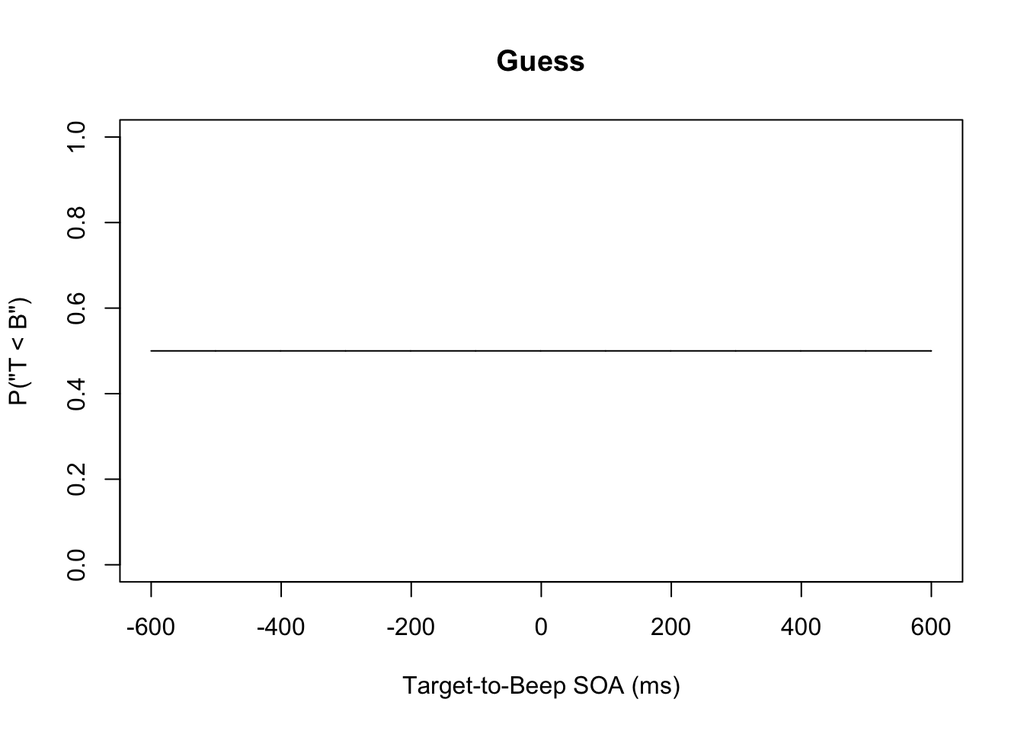

```r
plot.function(p.beforeBeep.guess, "black", "Guess")
```

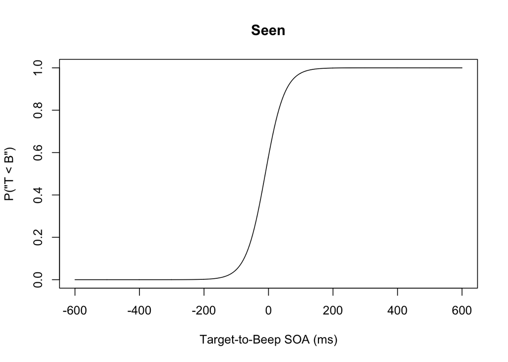

```r
plot.function(p.beforeBeep.seen, "black", "Seen")
```

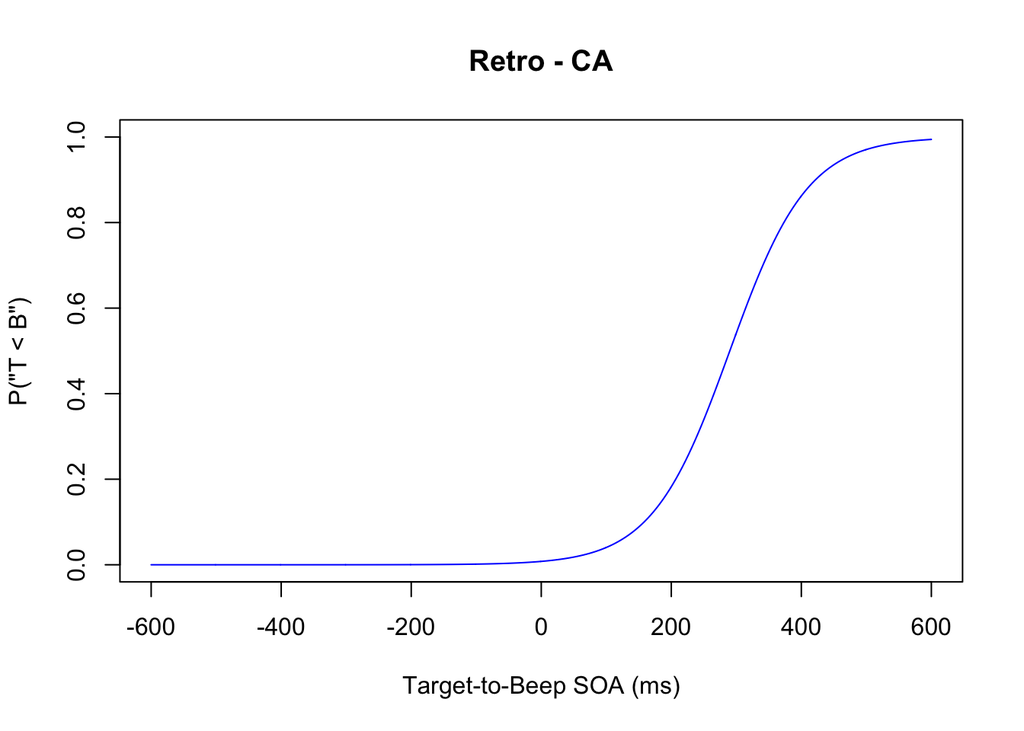

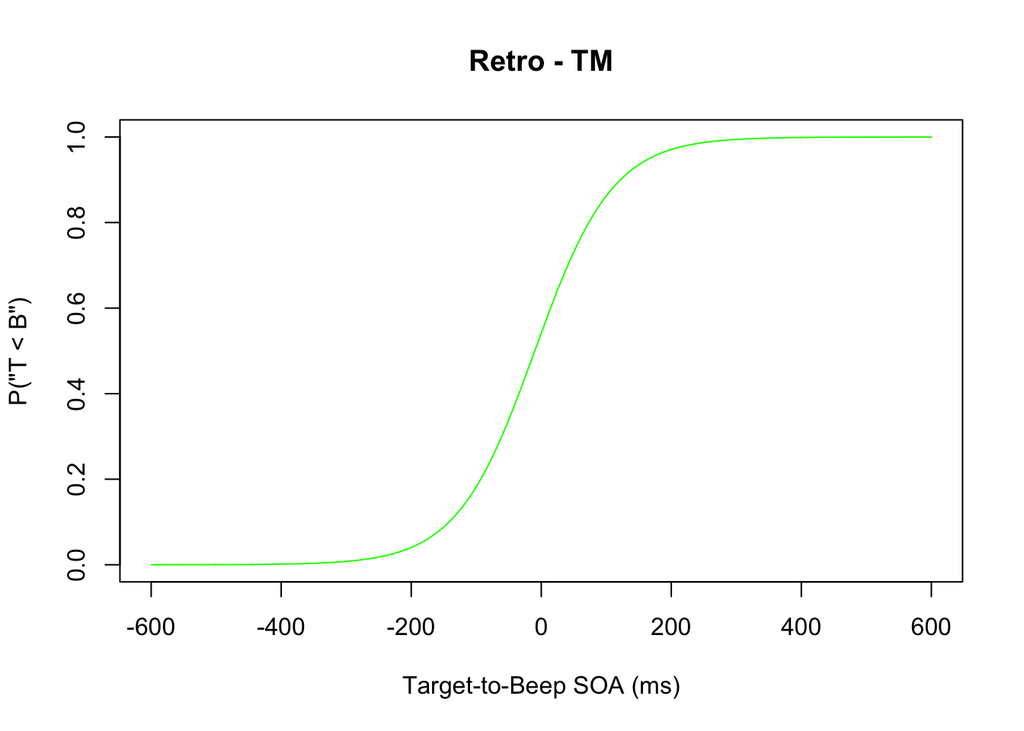

```r
for (model in models) {
  p.function.retro <- function(soa.toBeep) {
    p.beforeBeep.retro(soa.toBeep, data.soa.toCue, model$name)
  }
  plot.function(p.function.retro, model$color, sprintf("Retro - %s", model$name))
}
```

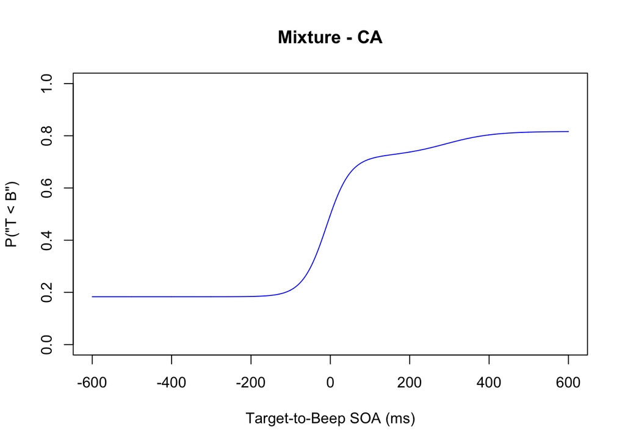

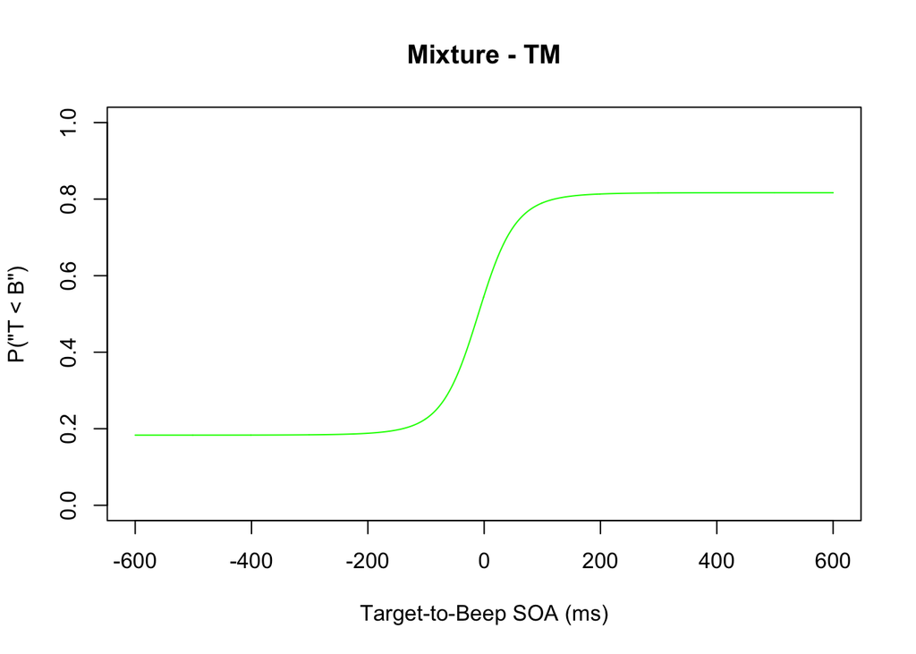

```r
for (model in models) {
  p.function.mixture <- function(soa.toBeep) {
    p.beforeBeep.mixture(data.soa.toBeep, data.soa.toCue, model$name, include.guesses)
  }
  plot.function(p.function.mixture, model$color, sprintf("Mixture - %s", model$name))
}
```

### Comparing cue present / cue absent

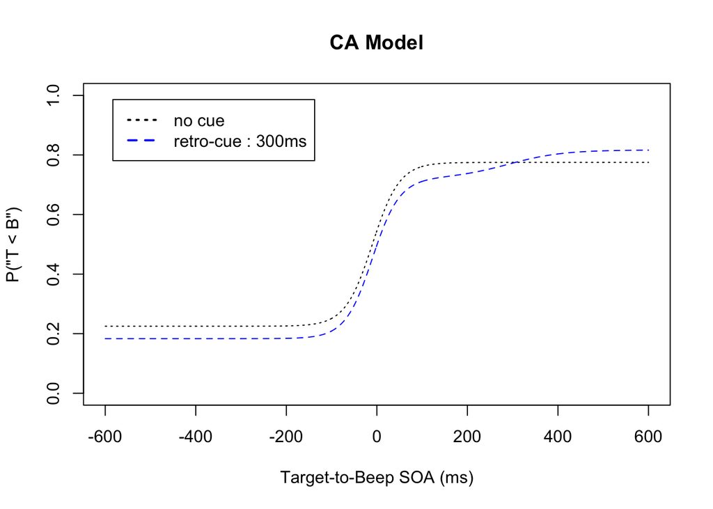

```r
plot.mixtures <- function(model, color) {
  plot(data.soa.toBeep, p.beforeBeep.mixture.nocue(data.soa.toBeep, include.guesses),
       type="l", col="black", lty="dotted",
       xlab="Target-to-Beep SOA (ms)", ylab="P(\"T < B\")",
       ylim=c(0,1),
       main=sprintf("%s Model", model))
  lines(data.soa.toBeep, p.beforeBeep.mixture(data.soa.toBeep, soa.toCue = data.soa.toCue, model, include.guesses),
        col=color, lty="dashed")
  legend("topleft", inset=.05, lwd=2,
         c("no cue", sprintf("retro-cue : %dms", data.soa.toCue)),
         col=c("black", color),
         lty=c("dotted", "dashed"))
}
plot.mixtures("CA", "blue")
```

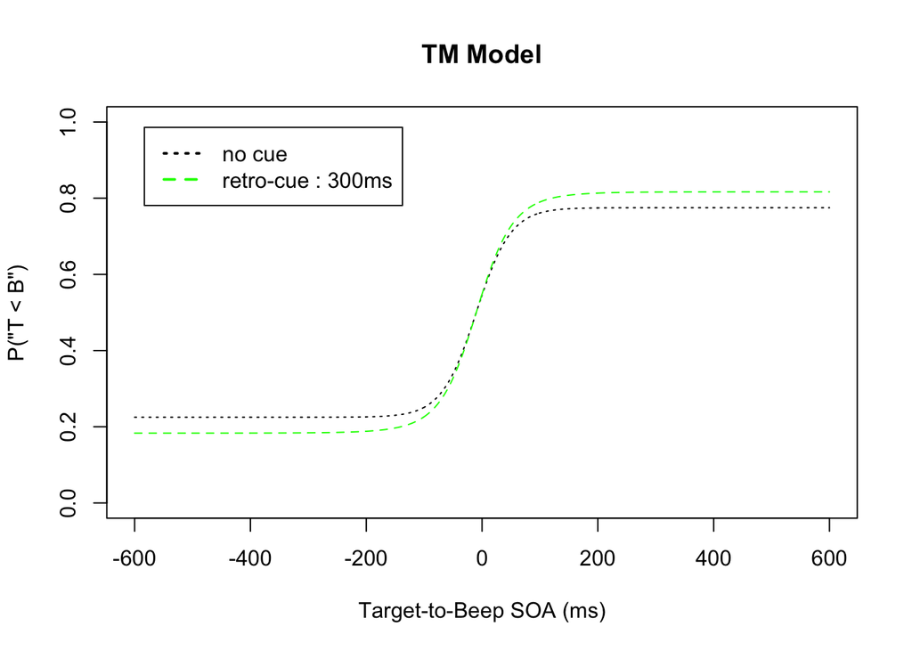

```r
plot.mixtures("TM", "green")
```

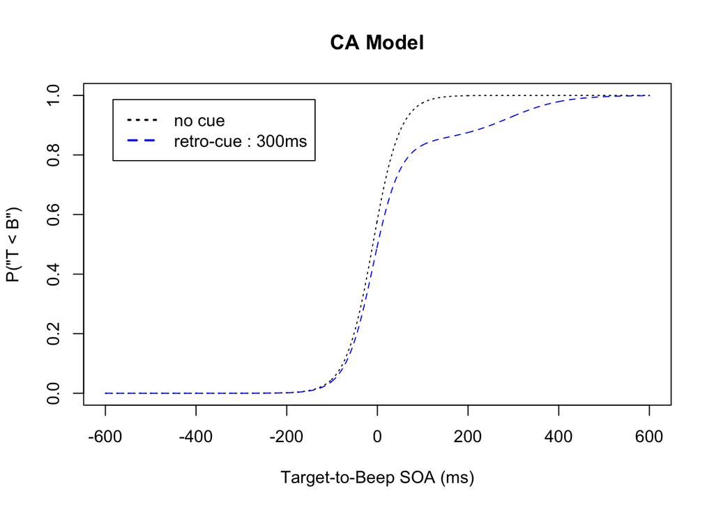

```r
include.guesses <- FALSE
plot.mixtures("CA", "blue")
```

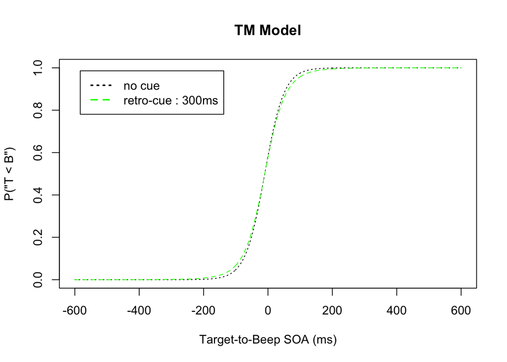

```r
plot.mixtures("TM", "green")
```